# 🌐 Radial Basis Functions and Classification

## 🔹 Radially Symmetric Property

- Each **Radial Basis Function (RBF) neuron** has a **center** (c_j).
- Its activation depends only on the **distance** from the input (x) to the center:

$$ \phi(x) = \phi(\|x - c_j\|) $$

- Because of this, the response is **the same in all directions** around the center.
- In 2D, the activation looks like a **circular bump**; in 3D, it’s a **spherical bump**; in higher dimensions, it’s a **hypersphere**.

## 🔹 Discovering Groups (Classes)

- During training, RBF centers are usually placed near clusters of data (e.g., using k‑means).
- Each center + radial function effectively represents one local region of the input space.
- The output layer then learns to **combine these radial activations** to decide which class the input belongs to.

✅ **Key Idea:**  
The **radially symmetric property** is exactly what allows RBFs to “discover” which group (class) an input belongs to.  
Inputs close to a class’s centers → **high activation** → classified into that group.

```r
# ================================================================
# RBF Neural Network Example
# ================================================================

# -----------------------------
# Step 1: Training Data
# -----------------------------
X <- matrix(c(1,1,
              2,1,
              4,3,
              5,4),
            ncol=2, byrow=TRUE)
colnames(X) <- c("x1","x2")

# Labels: Class A = [1,0], Class B = [0,1]
y <- matrix(c(1,0,   # point1
              1,0,   # point2
              0,1,   # point3
              0,1),  # point4
            ncol=2, byrow=TRUE)
colnames(y) <- c("ClassA","ClassB")

print("Training Data:")
print(X)
print("Target Labels:")
print(y)
```

```
[1] "Training Data:"
     x1 x2
[1,]  1  1
[2,]  2  1
[3,]  4  3
[4,]  5  4
[1] "Target Labels:"
     ClassA ClassB
[1,]      1      0
[2,]      1      0
[3,]      0      1
[4,]      0      1
```

```r
# -----------------------------
# Step 2: Hidden Layer Setup (K-means for centers)
# -----------------------------
set.seed(123)
k <- 2
km <- kmeans(X, centers=k, nstart=10)
centers <- km$centers
print("Cluster centers:")
print(centers)
```

```
[1] "Cluster centers:"
   x1  x2
1 1.5 1.0
2 4.5 3.5
```

```r
# -----------------------------
# Step 3: Compute Spread (sigma)
# -----------------------------
d_max <- dist(centers)  # distance between centers
m1 <- k
sigma <- as.numeric(d_max / sqrt(m1))
print(paste("d_max =", round(d_max,3)))
print(paste("sigma =", round(sigma,3)))
```

```
[1] "d_max = 3.905"
[1] "sigma = 2.761"
```

```r
# -----------------------------
# Step 4: Define RBF Function
# -----------------------------
rbf <- function(x, center, d_max, m1) {
  dist2 <- sum((x - center)^2)
  phi <- exp(-(m1 / (d_max^2)) * dist2)
  return(phi)
}
```

```r
# -----------------------------
# Step 5: Build Hidden Activation Matrix H
# -----------------------------
H <- matrix(0, nrow=nrow(X), ncol=k)
for (i in 1:nrow(X)) {
  for (j in 1:k) {
    H[i,j] <- rbf(X[i,], centers[j,], d_max, m1)
  }
}
colnames(H) <- paste0("Neuron",1:k)
rownames(H) <- paste0("Point",1:nrow(X))
print("Hidden activations (H):")
print(round(H,3))
```

```
[1] "Hidden activations (H):"
       Neuron1 Neuron2
Point1   0.968   0.088
Point2   0.968   0.194
Point3   0.261   0.937
Point4   0.062   0.937
```

```r
# -----------------------------
# Step 6: Train Output Weights W (linear regression)
# -----------------------------
W <- solve(t(H) %*% H) %*% t(H) %*% y
print("Trained output weights W:")
print(round(W,3))
```

```
[1] "Trained output weights W:"
        ClassA ClassB
Neuron1  1.048 -0.157
Neuron2 -0.178  1.091
```

```r
# -----------------------------
# Step 7: Define Prediction Function (forward pass)
# -----------------------------
rbf_predict <- function(newX, centers, d_max, m1, W) {
  H_new <- matrix(0, nrow=nrow(newX), ncol=nrow(centers))
  for (i in 1:nrow(newX)) {
    for (j in 1:nrow(centers)) {
      H_new[i,j] <- rbf(newX[i,], centers[j,], d_max, m1)
    }
  }
  y_pred <- H_new %*% W
  class_pred <- apply(y_pred, 1, which.max)
  return(list(predictions=y_pred, class=class_pred))
}
```

```r
# -----------------------------
# Step 8: Test on Training Data
# -----------------------------
result_train <- rbf_predict(X, centers, d_max, m1, W)
print("Predicted outputs (training data):")
print(round(result_train$predictions,3))
print("Predicted classes (training data):")
print(result_train$class)
```

```
[1] "Predicted outputs (training data):"
     ClassA ClassB
[1,]  0.998 -0.055
[2,]  0.979  0.060
[3,]  0.107  0.981
[4,] -0.102  1.012
[1] "Predicted classes (training data):"
[1] 1 1 2 2
```

```r
# -----------------------------
# Step 9: Test on Unseen Data
# -----------------------------
X_test <- matrix(c(3,2,   # new point near middle
                   6,5),  # new point near Class B
                 ncol=2, byrow=TRUE)
colnames(X_test) <- c("x1","x2")
print("Unseen test points:")
print(X_test)

result_test <- rbf_predict(X_test, centers, d_max, m1, W)
print("Predicted outputs (test data):")
print(round(result_test$predictions,3))
print("Predicted classes (test data):")
print(result_test$class)
```

```
[1] "Unseen test points:"
     x1 x2
[1,]  3  2
[2,]  6  5
[1] "Predicted outputs (test data):"
     ClassA ClassB
[1,]  0.586  0.502
[2,] -0.090  0.603
[1] "Predicted classes (test data):"
[1] 1 2
```

```r
# -----------------------------
# Step 8: Test on Training Data
# -----------------------------
result_train <- rbf_predict(X, centers, d_max, m1, W)
cat("\n--- Training Data Results ---\n")
print(data.frame(
  Actual = apply(y,1,which.max),
  Predicted = result_train$class
))
print("Predicted outputs (training data):")
print(round(result_train$predictions,3))
```

```
--- Training Data Results ---
  Actual Predicted
1      1         1
2      1         1
3      2         2
4      2         2
[1] "Predicted outputs (training data):"
     ClassA ClassB
[1,]  0.998 -0.055
[2,]  0.979  0.060
[3,]  0.107  0.981
[4,] -0.102  1.012
```

```r
# -----------------------------
# Step 9: Test on Unseen Data
# -----------------------------
X_test <- matrix(c(3,2,   # new point near middle
                   6,5),  # new point near Class B
                 ncol=2, byrow=TRUE)
colnames(X_test) <- c("x1","x2")
cat("\n--- Test Data Results ---\n")
print(X_test)
print("Predicted outputs (test data):")
print(round(result_test$predictions,3))
print("Predicted classes (test data):")
print(result_test$class)
```

```
--- Test Data Results ---
     x1 x2
[1,]  3  2
[2,]  6  5
[1] "Predicted outputs (test data):"
     ClassA ClassB
[1,]  0.586  0.502
[2,] -0.090  0.603
[1] "Predicted classes (test data):"
[1] 1 2
```

```r
# Training evaluation
actual_train <- apply(y, 1, which.max)
pred_train <- result_train$class

cat("\nConfusion Matrix (Training):\n")
print(table(Actual=actual_train, Predicted=pred_train))

error_rate_train <- mean(actual_train != pred_train)
cat("Training Error Rate:", error_rate_train, "\n")
```

```
Confusion Matrix (Training):
      Predicted
Actual 1 2
     1 2 0
     2 0 2
Training Error Rate: 0
```

```
Global σ = 3.464102
Local σ per neuron = 1.5 1.5 1.5
```

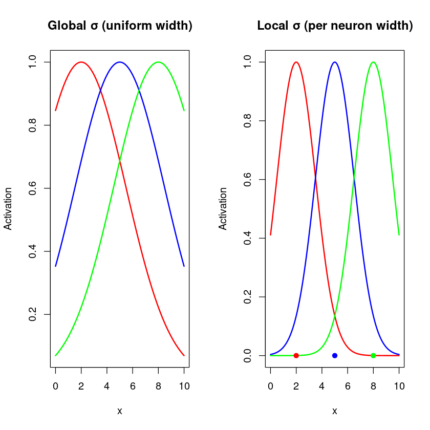

```r
# ================================================================
# RBF Neurons: Global σ vs Local σ (1D Visualization)
# ================================================================

# -----------------------------
# Step 1: Define centers
# -----------------------------
centers <- c(2, 5, 8)  # 3 neuron centers
k <- length(centers)

# -----------------------------
# Step 2: Compute Global σ
# -----------------------------
d_max <- max(centers) - min(centers)
sigma_global <- d_max / sqrt(k)

# -----------------------------
# Step 3: Compute Local σ (nearest neighbor distance / 2)
# -----------------------------
sigmas_local <- numeric(k)
for (i in 1:k) {
  others <- centers[-i]
  nearest <- min(abs(others - centers[i]))
  sigmas_local[i] <- nearest/2
}

cat("Global σ =", sigma_global, "\n")
cat("Local σ per neuron =", sigmas_local, "\n")

# -----------------------------
# Step 4: Define RBF function
# -----------------------------
rbf <- function(x, center, sigma) {
  exp(- (x-center)^2 / (2*sigma^2))
}

# -----------------------------
# Step 5: Generate curve data
# -----------------------------
x_vals <- seq(0, 10, length.out=200)

# Global σ curves
H_global <- sapply(1:k, function(j) rbf(x_vals, centers[j], sigma_global))

# Local σ curves
H_local <- sapply(1:k, function(j) rbf(x_vals, centers[j], sigmas_local[j]))

# -----------------------------
# Step 6: Plot Global σ
# -----------------------------
par(mfrow=c(1,2))  # two plots side by side
matplot(x_vals, H_global, type="l", lwd=2, lty=1,
        col=c("red","blue","green"),
        main="Global σ (uniform width)",
        xlab="x", ylab="Activation")
points(centers, rep(0,k), pch=19, col=c("red","blue","green"))

# -----------------------------
# Step 7: Plot Local σ
# -----------------------------
matplot(x_vals, H_local, type="l", lwd=2, lty=1,
        col=c("red","blue","green"),
        main="Local σ (per neuron width)",
        xlab="x", ylab="Activation")
points(centers, rep(0,k), pch=19, col=c("red","blue","green"))

par(mfrow=c(1,1))  # reset layout
```

```
Fixed σ (40% of input range) = 2.4
```

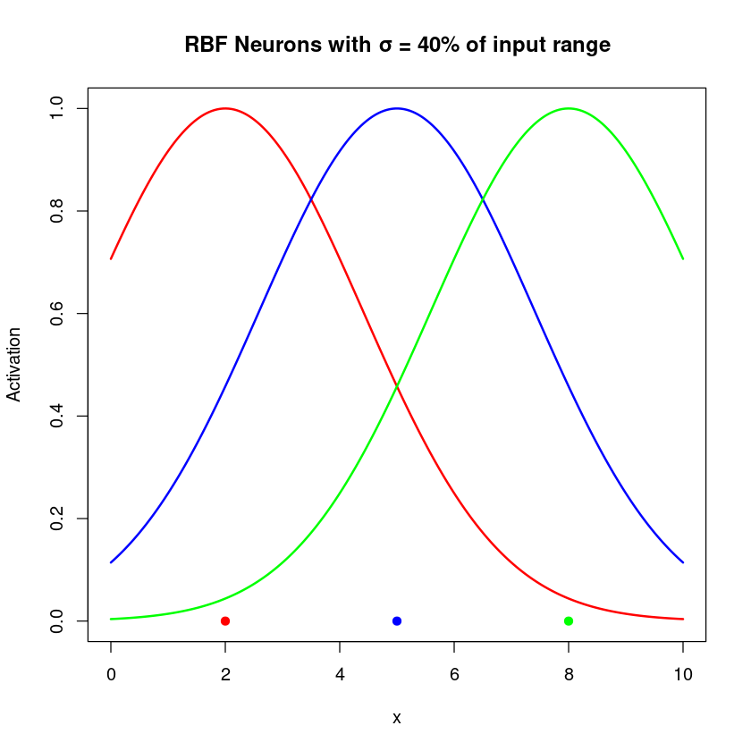

```r
# ================================================================
# RBF Neurons with Fixed Width (40% of input range)
# ================================================================

# Step 1: Define centers
centers <- c(2, 5, 8)   # neuron centers
k <- length(centers)

# Step 2: Compute 40% width
d_max <- max(centers) - min(centers)
sigma_fixed <- 0.4 * d_max
cat("Fixed σ (40% of input range) =", sigma_fixed, "\n")

# Step 3: RBF function
rbf <- function(x, center, sigma) {
  exp(- (x-center)^2 / (2*sigma^2))
}

# Step 4: Generate curve data
x_vals <- seq(0, 10, length.out=200)
H_fixed <- sapply(1:k, function(j) rbf(x_vals, centers[j], sigma_fixed))

# Step 5: Plot
matplot(x_vals, H_fixed, type="l", lwd=2, lty=1,
        col=c("red","blue","green"),
        main="RBF Neurons with σ = 40% of input range",
        xlab="x", ylab="Activation", ylim=c(0,1))
points(centers, rep(0,k), pch=19, col=c("red","blue","green"))
```

```
Global σ (40% of input range) = 2.4
Local σ per neuron = 1.5 1.5 1.5
```

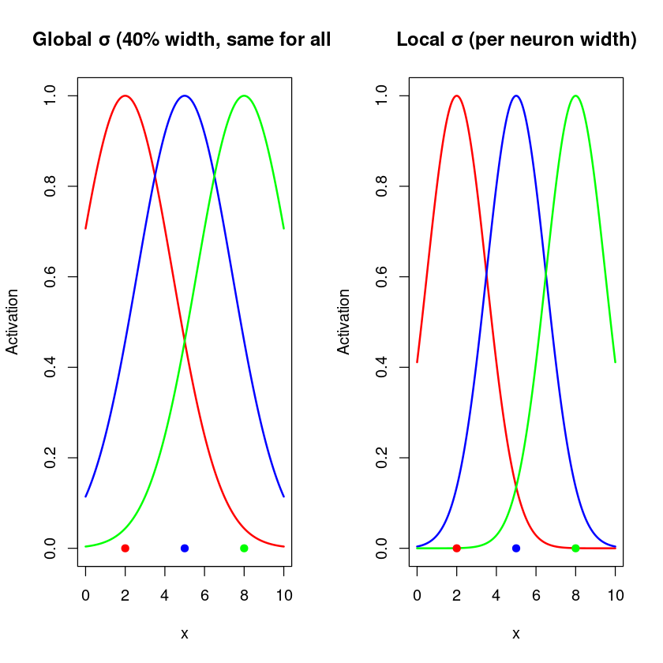

```r
# ================================================================
# RBF Neurons: Global σ vs Local σ (with 40% width for global)
# ================================================================

# Step 1: Define centers
centers <- c(2, 5, 8)   # neuron centers
k <- length(centers)

# Step 2: Compute Global σ (fixed at 40% of range)
d_max <- max(centers) - min(centers)
sigma_global <- 0.4 * d_max   # 40% of span
cat("Global σ (40% of input range) =", sigma_global, "\n")

# Step 3: Compute Local σ (nearest neighbor distance / 2)
sigmas_local <- numeric(k)
for (i in 1:k) {
  others <- centers[-i]
  nearest <- min(abs(others - centers[i]))
  sigmas_local[i] <- nearest/2
}
cat("Local σ per neuron =", sigmas_local, "\n")

# Step 4: RBF function
rbf <- function(x, center, sigma) {
  exp(- (x-center)^2 / (2*sigma^2))
}

# Step 5: Generate curve data
x_vals <- seq(0, 10, length.out=300)
H_global <- sapply(1:k, function(j) rbf(x_vals, centers[j], sigma_global))
H_local  <- sapply(1:k, function(j) rbf(x_vals, centers[j], sigmas_local[j]))

# Step 6: Plot Global vs Local
par(mfrow=c(1,2))  # two plots side by side

# --- Global σ ---
matplot(x_vals, H_global, type="l", lwd=2, lty=1,
        col=c("red","blue","green"),
        main="Global σ (40% width, same for all)",
        xlab="x", ylab="Activation", ylim=c(0,1))
points(centers, rep(0,k), pch=19, col=c("red","blue","green"))

# --- Local σ ---
matplot(x_vals, H_local, type="l", lwd=2, lty=1,
        col=c("red","blue","green"),
        main="Local σ (per neuron width)",
        xlab="x", ylab="Activation", ylim=c(0,1))
points(centers, rep(0,k), pch=19, col=c("red","blue","green"))

par(mfrow=c(1,1))  # reset
```